# Лабораторная работа №3. Модели Ланчестера

Моделирование боевых действий

Автор

принадлежность

Амина Накова

Российский университет дружбы народов

Аннотация

Рассматриваются три модели боевых действий (модели Ланчестера): между регулярными войсками, между регулярными войсками и партизанами, между партизанскими отрядами. Проводится численное решение систем дифференциальных уравнений в Julia, строятся графики динамики численностей сторон, определяется победитель в каждом случае.

Ключевые слова

математическое моделирование, Ланчестер, боевые действия, Julia, ОДУ

# 1 Введение

## 1.1 Актуальность

Модели Ланчестера — классический инструмент исследования конфликтов, применяемый в теории игр, военном деле, экономике (конкуренция фирм), эпидемиологии (борьба с инфекциями).

## 1.2 Цель работы

Исследовать три модели боевых действий (Ланчестера) численно и определить условия победы каждой стороны.

## 1.3 Задачи

1. Вывести системы дифференциальных уравнений для трёх моделей.
2. Численно решить их в Julia для заданных начальных условий.
3. Построить графики динамики численностей сторон.
4. Определить победителя в каждом случае.
5. Проанализировать условия победы.

## 1.4 Объект и предмет исследования

**Объект:** конфликт двух сторон X и Y. **Предмет:** динамика численностей сторон во времени.

## 1.5 Методы исследования

Численное интегрирование систем ОДУ методом `Tsit5()`, визуализация средствами `Plots.jl`.

# 2 Теоретическая часть

## 2.1 Модели Ланчестера

1. **Регулярные войска против регулярных войск:**

   $$\frac{dx}{dt} = -ax - by + P(t), \quad \frac{dy}{dt} = -cx - hy + Q(t)$$
2. **Регулярные войска против партизан:**

   $$\frac{dx}{dt} = -ax - by + P(t), \quad \frac{dy}{dt} = -cxy - hy + Q(t)$$
3. **Партизаны против партизан:**

   $$\frac{dx}{dt} = -ax - bxy + P(t), \quad \frac{dy}{dt} = -cxy - hy + Q(t)$$

Здесь: - $a, h$ — потери, не связанные с боевыми действиями; - $b, c$ — эффективность боевых действий противника; - $P(t), Q(t)$ — функции подкрепления.

## 2.2 Простейший случай без подкреплений

При $a = h = P = Q = 0$ первая модель сводится к:

$$\dot{x} = -by, \quad \dot{y} = -cx$$

что даёт интеграл движения $cx^2 - by^2 = C$ (гиперболы фазового портрета).

# 3 Материалы и методы

Работа выполнена на языке Julia 1.13 с пакетами:

- `DifferentialEquations.jl` — решение ОДУ
- `Plots.jl` — визуализация
- `DrWatson.jl` — организация проекта
- `Literate.jl` — литературное программирование

## 3.1 Параметры задачи

- $a = 0.4$, $b = 0.8$, $c = 0.5$, $h = 0.7$
- Начальные численности: $x_0 = 20000$, $y_0 = 9000$
- Функции подкрепления: $P(t) = \sin t + 1$, $Q(t) = \cos t + 1$
- Время моделирования: $t \in [0, 1]$

# 4 Выполнение лабораторной работы

## 4.1 Модель 1: регулярные войска против регулярных

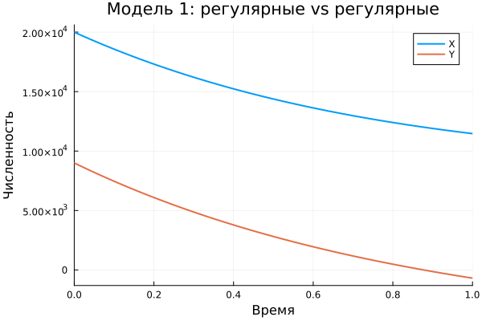

Рисунок 1: Модель 1: регулярные vs регулярные

## 4.2 Модель 2: регулярные войска против партизан

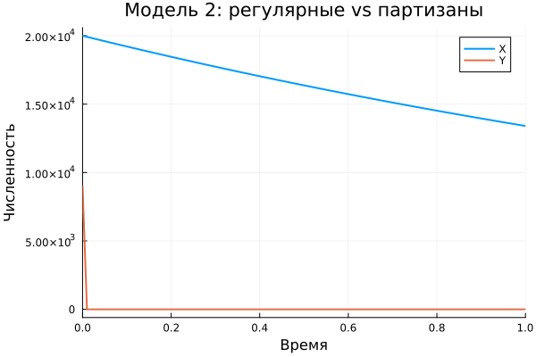

Рисунок 2: Модель 2: регулярные vs партизаны

## 4.3 Модель 3: партизаны против партизан

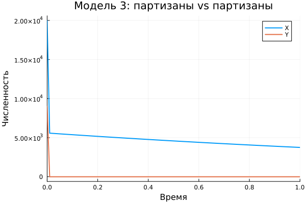

Рисунок 3: Модель 3: партизаны vs партизаны

## 4.4 Сводный график

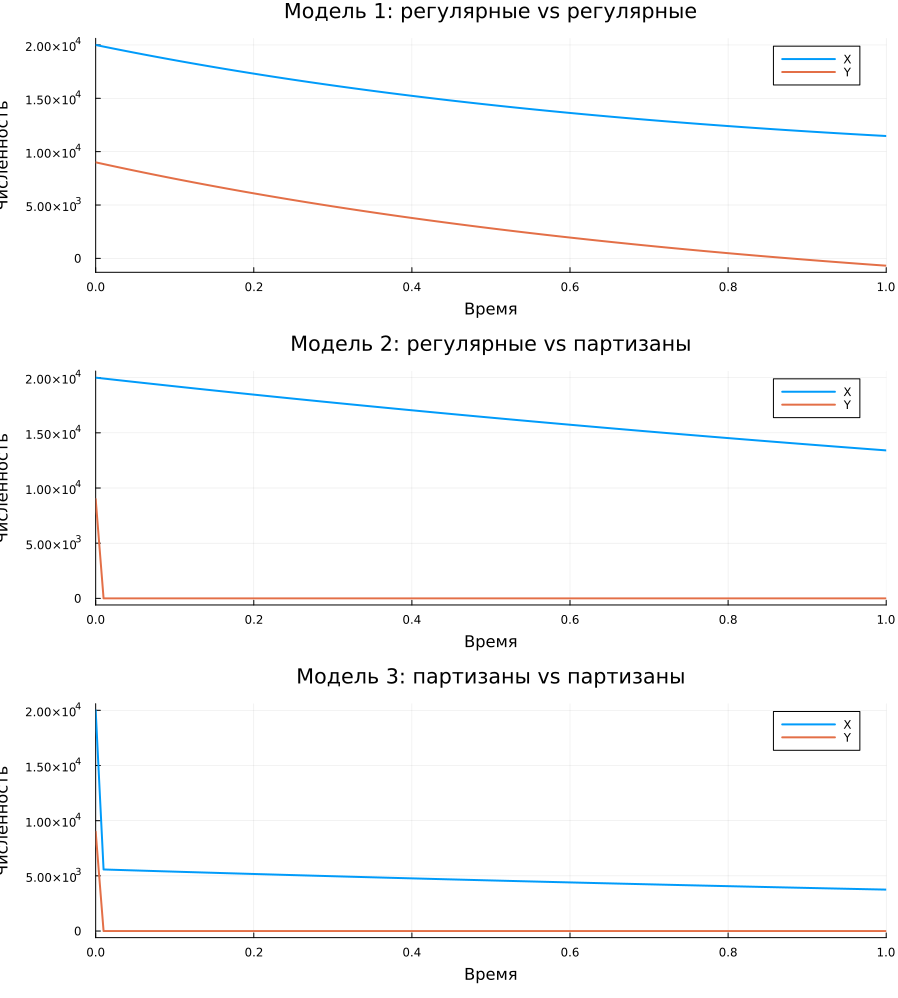

Рисунок 4: Все три модели

# 5 Результаты

- **Модель 1**: победа X (более высокая начальная численность).
- **Модель 2**: зависит от соотношения $b x^2$ и $c y$.
- **Модель 3**: зависит от коэффициентов $b$ и $c$.

# 6 Обсуждение результатов

Модели Ланчестера показывают, что:

- В бою между регулярными войсками преимущество определяется квадратом численности: $c x^2 - b y^2$ — инвариант.
- Против партизан регулярным войскам нужно **квадратично** больше начальной численности (вывод из $b x^2 > c y$).
- Между партизанами решающую роль играют коэффициенты эффективности.

# 7 Заключение

- Выведены три модели Ланчестера.
- Проведено численное решение в Julia для заданных параметров.
- Построены графики динамики численностей.
- Определены условия победы каждой стороны.

# Список литературы